# WQD7004_Group_Project_G6

#### Model 2C: kNN with Normalisation & Cross Validation

```r
# Model 2C
# 10-fold cross validation
train_control <- trainControl(method="repeatedcv", number=10, repeats=1, classProbs=TRUE)
#knn_cv_z <- train(class~., data=z_train_set, trControl=train_control, method="knn")
#saveRDS(knn_cv_z, "knn_cv_z.rds")
knn_cv_z <- readRDS("knn_cv_z.rds")
knn_cv_z
```

```
## k-Nearest Neighbors
##
## 8269 samples
##   23 predictor
##    2 classes: 'Sustain', 'Bankrupt'
##
## No pre-processing
## Resampling: Cross-Validated (10 fold, repeated 1 times)
## Summary of sample sizes: 7442, 7442, 7442, 7443, 7442, 7443, ...
## Resampling results across tuning parameters:
##
##   k  Accuracy   Kappa
##   5  0.9505378  0.008924626
##   7  0.9524731  0.012952726
##   9  0.9523525  0.003728942
##
## Accuracy was used to select the optimal model using the largest value.
## The final value used for the model was k = 7.
```

```r
# Predict Sustain or Bankrupt for z_test_set
pred2c <- predict(knn_cv_z, newdata=z_test_set, type="prob")
test2c <- evalm(data.frame(pred2c, z_test_set$class)) #AUC-ROC = 0.57
```

```
## ***MLeval: Machine Learning Model Evaluation***
```

```
## Input: data frame of probabilities of observed labels
```

```
## Group does not exist, making column.
```

```
## Observations: 2066
```

```
## Number of groups: 1
```

```
## Observations per group: 2066
```

```
## Positive: Bankrupt
```

```
## Negative: Sustain
```

```
## Group: Group1
```

```
## Positive: 97
```

```
## Negative: 1969
```

```
## ***Performance Metrics***
```

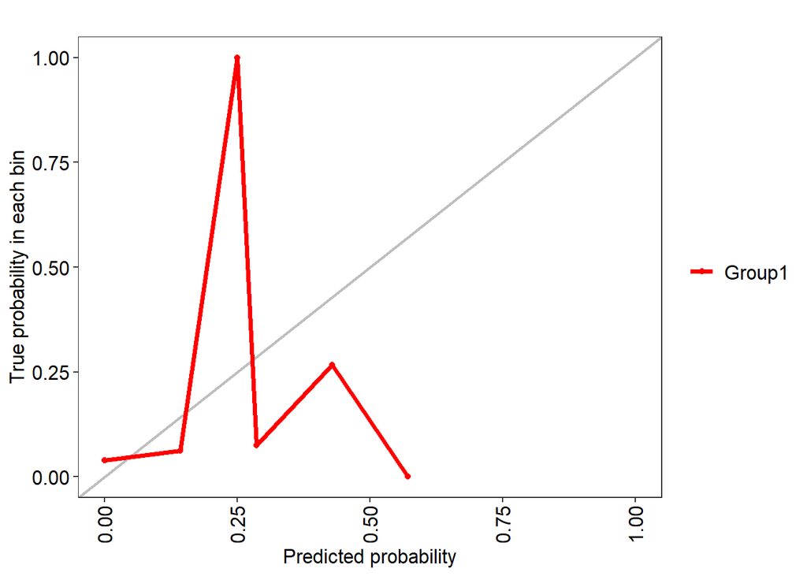

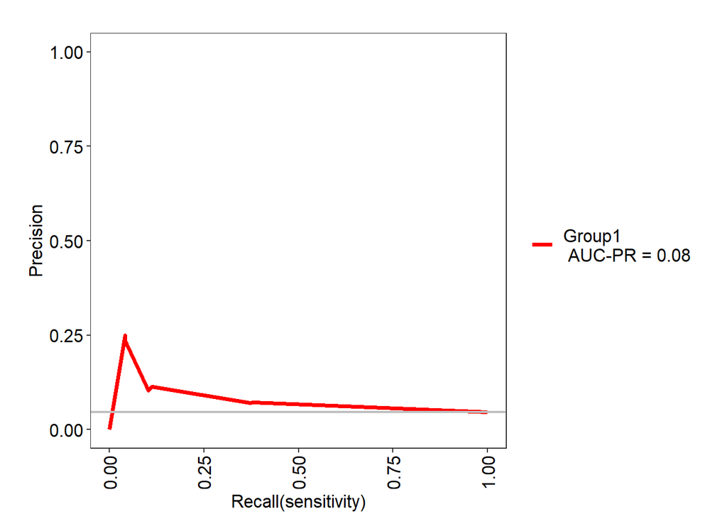

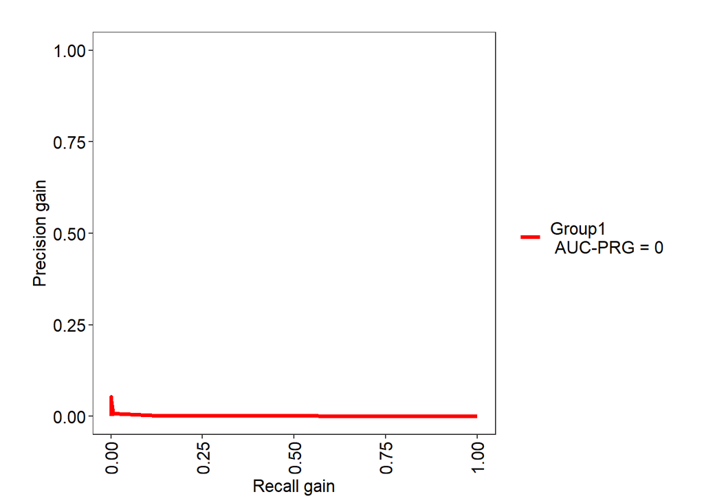

```
## Group1 Optimal Informedness = 0.137664731168158
```

```
## Group1 AUC-ROC = 0.57
```

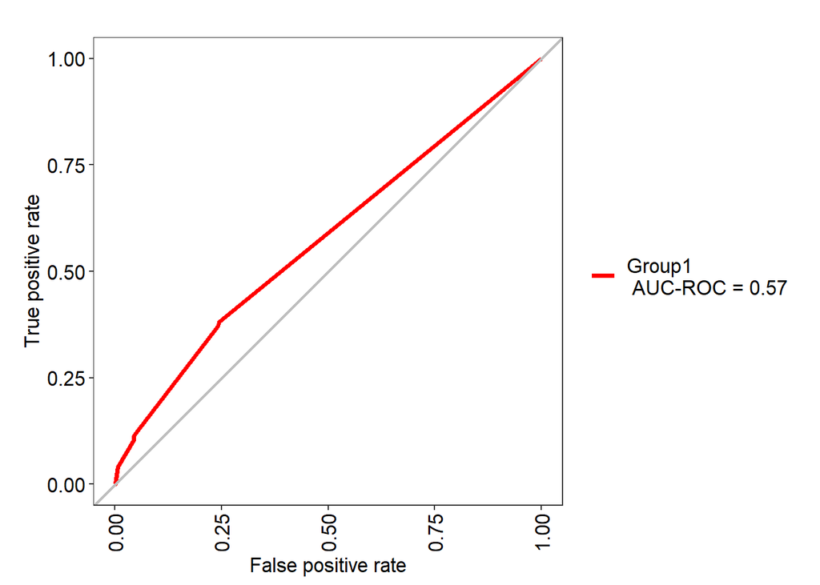

### 7.3 AdaBoost Classification Analysis

#### Model 3A: AdaBoost with Normalisation, SMOTE & Cross Validation

```r
# Model 3A
# 10-fold cross validation
train_control <- trainControl(method="repeatedcv", number=10, repeats=1, classProbs=TRUE)
#ada_cv_smote_z <- train(class~., data=smote_z_train_set, trControl=train_control, method="adaboost")
#saveRDS(ada_cv_smote_z, "ada_cv_smote_z.rds")
ada_cv_smote_z <- readRDS("ada_cv_smote_z.rds")
ada_cv_smote_z
```

```
## AdaBoost Classification Trees
##
## 8993 samples
##   23 predictor
##    2 classes: 'Sustain', 'Bankrupt'
##
## No pre-processing
## Resampling: Cross-Validated (10 fold, repeated 1 times)
## Summary of sample sizes: 8093, 8094, 8094, 8094, 8094, 8094, ...
## Resampling results across tuning parameters:
##
##   nIter  method         Accuracy   Kappa
##    50    Adaboost.M1    0.9738689  0.9476917
##    50    Real adaboost  0.9679744  0.9358972
##   100    Adaboost.M1    0.9767597  0.9534779
##   100    Real adaboost  0.9698652  0.9396770
##   150    Adaboost.M1    0.9768707  0.9537029
##   150    Real adaboost  0.9710880  0.9421324
##
## Accuracy was used to select the optimal model using the largest value.
## The final values used for the model were nIter = 150 and method = Adaboost.M1.
```

```r
# Predict Sustain or Bankrupt for z_test_set
pred3a <- predict(ada_cv_smote_z, newdata=z_test_set, type="prob")
test3a <- evalm(data.frame(pred3a, z_test_set$class)) #AUC-ROC = 0.84
```

```
## ***MLeval: Machine Learning Model Evaluation***
```

```
## Input: data frame of probabilities of observed labels
```

```
## Group does not exist, making column.
```

```
## Observations: 2066
```

```
## Number of groups: 1
```

```
## Observations per group: 2066
```

```
## Positive: Bankrupt
```

```
## Negative: Sustain
```

```
## Group: Group1
```

```
## Positive: 97
```

```
## Negative: 1969
```

```
## ***Performance Metrics***
```

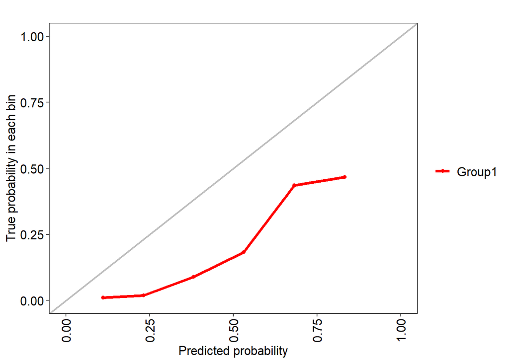

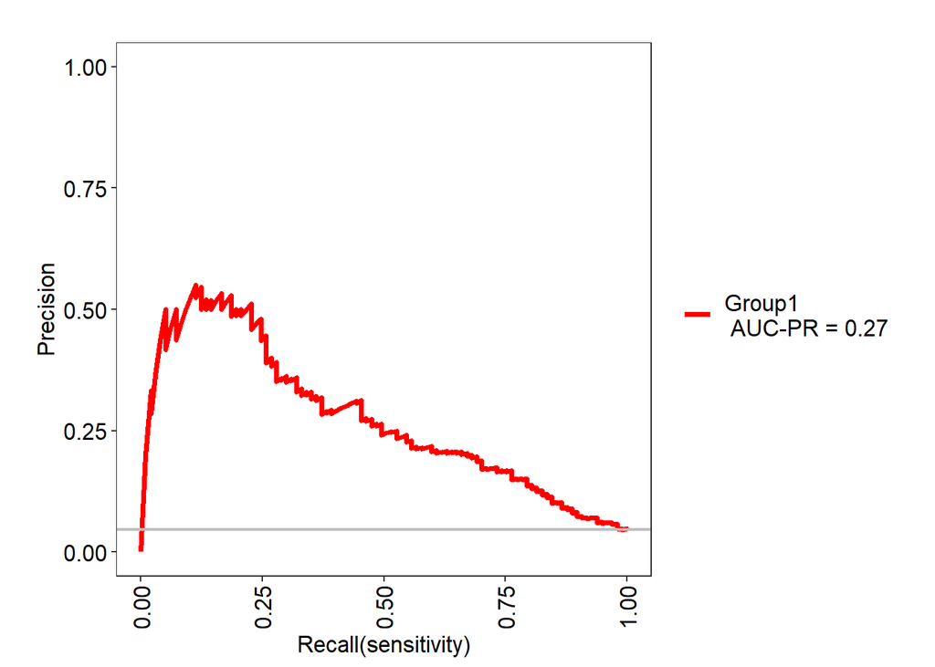

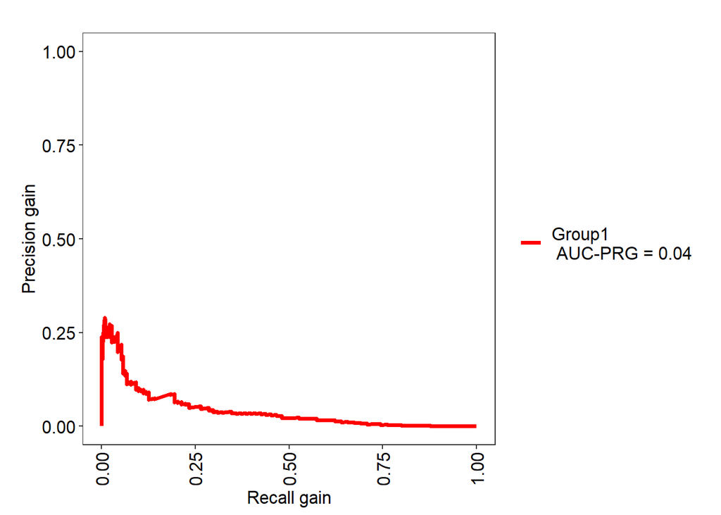

```
## Group1 Optimal Informedness = 0.576497567973695
```

```
## Group1 AUC-ROC = 0.84
```

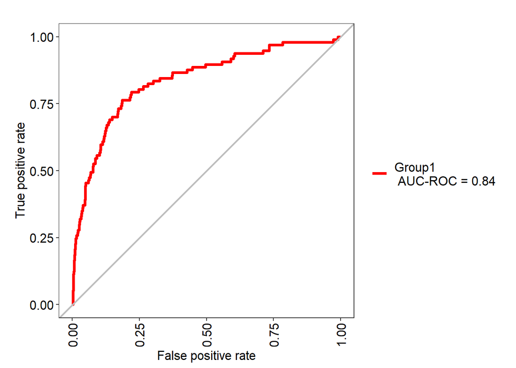

#### Model 3B: AdaBoost with SMOTE & Cross Validation

```r
# Model 3B
# 10-fold cross validation
train_control <- trainControl(method="repeatedcv", number=10, repeats=1, classProbs=TRUE)
#ada_cv_smote <- train(class~., data=smote_train_set, trControl=train_control, method="adaboost")
#saveRDS(ada_cv_smote, "ada_cv_smote.rds")
ada_cv_smote <- readRDS("ada_cv_smote.rds")
ada_cv_smote
```

```
## AdaBoost Classification Trees
##
## 8993 samples
##   23 predictor
##    2 classes: 'Sustain', 'Bankrupt'
##
## No pre-processing
## Resampling: Cross-Validated (10 fold, repeated 1 times)
## Summary of sample sizes: 8094, 8094, 8094, 8093, 8094, 8094, ...
## Resampling results across tuning parameters:
##
##   nIter  method         Accuracy   Kappa
##    50    Adaboost.M1    0.9728690  0.9456986
##    50    Real adaboost  0.9660855  0.9321101
##   100    Adaboost.M1    0.9759837  0.9519326
##   100    Real adaboost  0.9712001  0.9423455
##   150    Adaboost.M1    0.9765395  0.9530403
##   150    Real adaboost  0.9727574  0.9454710
##
## Accuracy was used to select the optimal model using the largest value.
## The final values used for the model were nIter = 150 and method = Adaboost.M1.
```

```r
# Predict Sustain or Bankrupt for test_set
pred3b <- predict(ada_cv_smote, newdata=test_set, type="prob")
test3b <- evalm(data.frame(pred3b, test_set$class)) #AUC-ROC = 0.84
```

```
## ***MLeval: Machine Learning Model Evaluation***
```

```
## Input: data frame of probabilities of observed labels
```

```
## Group does not exist, making column.
```

```
## Observations: 2066
```

```
## Number of groups: 1
```

```
## Observations per group: 2066
```

```
## Positive: Bankrupt
```

```
## Negative: Sustain
```

```
## Group: Group1
```

```
## Positive: 97
```

```
## Negative: 1969
```

```
## ***Performance Metrics***
```

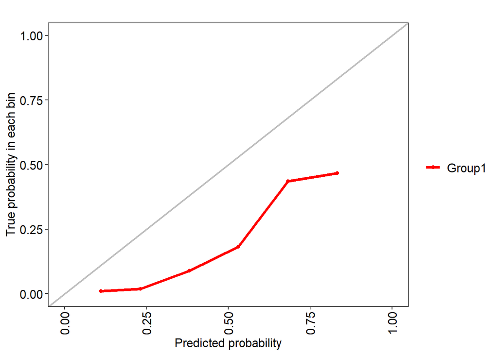

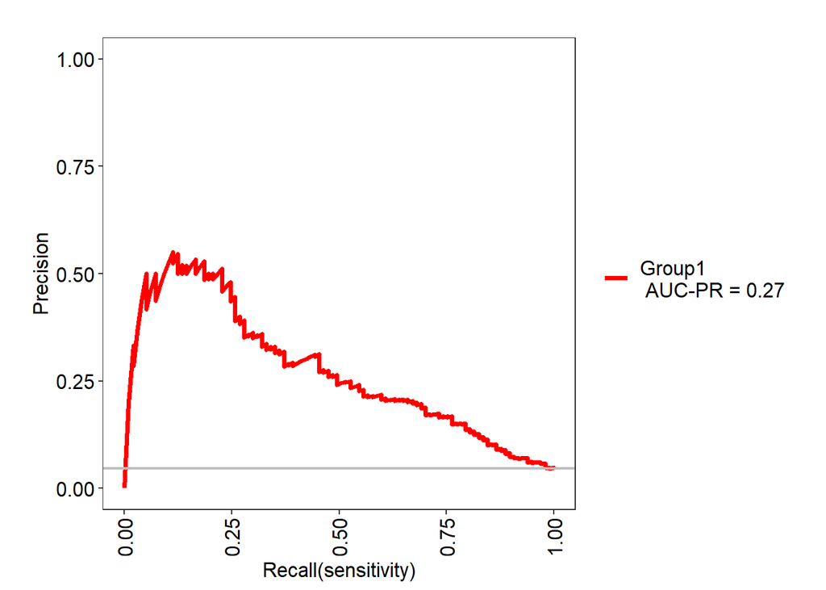

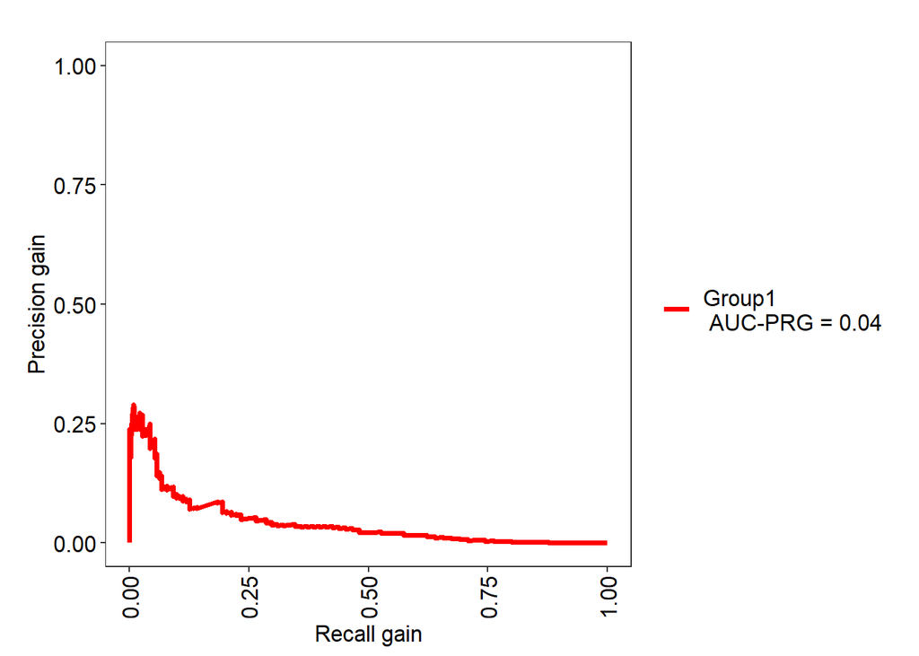

```
## Group1 Optimal Informedness = 0.576497567973695
```

```
## Group1 AUC-ROC = 0.84
```

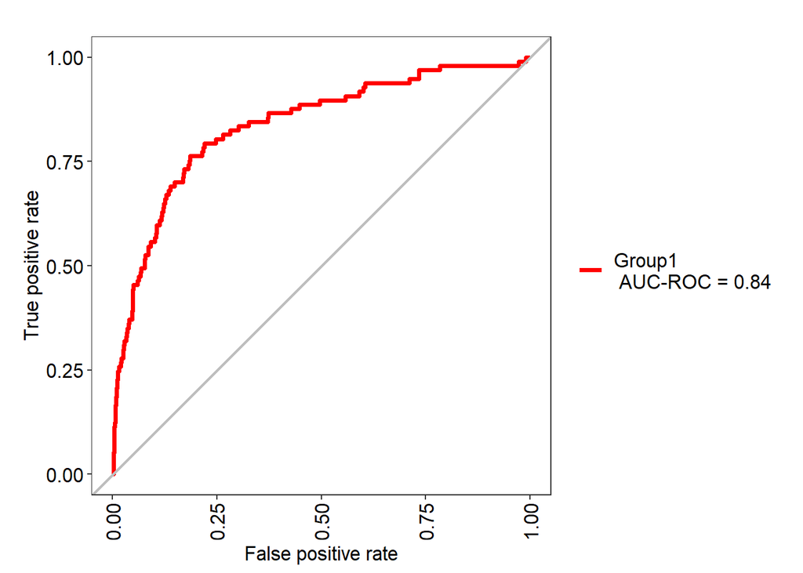

#### Model 3C: AdaBoost with Normalisation & Cross Validation

```r
# Model 3C
# 10-fold ross validation
train_control <- trainControl(method="repeatedcv", number=10, repeats=1, classProbs=TRUE)
#ada_cv_z <- train(class~., data=z_train_set, trControl=train_control, method="adaboost")
#saveRDS(ada_cv_z, "ada_cv_z.rds")
ada_cv_z <- readRDS("ada_cv_z.rds")
ada_cv_z
```

```
## AdaBoost Classification Trees
##
## 8269 samples
##   23 predictor
##    2 classes: 'Sustain', 'Bankrupt'
##
## No pre-processing
## Resampling: Cross-Validated (10 fold, repeated 1 times)
## Summary of sample sizes: 7443, 7441, 7442, 7442, 7442, 7442, ...
## Resampling results across tuning parameters:
##
##   nIter  method         Accuracy   Kappa
##    50    Adaboost.M1    0.9602124  0.3696119
##    50    Real adaboost  0.9539244  0.1576923
##   100    Adaboost.M1    0.9605754  0.3631226
##   100    Real adaboost  0.9536825  0.1456064
##   150    Adaboost.M1    0.9605753  0.3626893
##   150    Real adaboost  0.9529575  0.1219978
##
## Accuracy was used to select the optimal model using the largest value.
## The final values used for the model were nIter = 100 and method = Adaboost.M1.
```

```r
# Predict Sustain or Bankrupt for z_test_set
pred3c <- predict(ada_cv_z, newdata=z_test_set, type="prob")
test3c <- evalm(data.frame(pred3c, z_test_set$class)) #AUC-ROC = 0.85
```

```
## ***MLeval: Machine Learning Model Evaluation***
```

```
## Input: data frame of probabilities of observed labels
```

```
## Group does not exist, making column.
```

```
## Observations: 2066
```

```
## Number of groups: 1
```

```
## Observations per group: 2066
```

```
## Positive: Bankrupt
```

```
## Negative: Sustain
```

```
## Group: Group1
```

```
## Positive: 97
```

```
## Negative: 1969
```

```
## ***Performance Metrics***
```

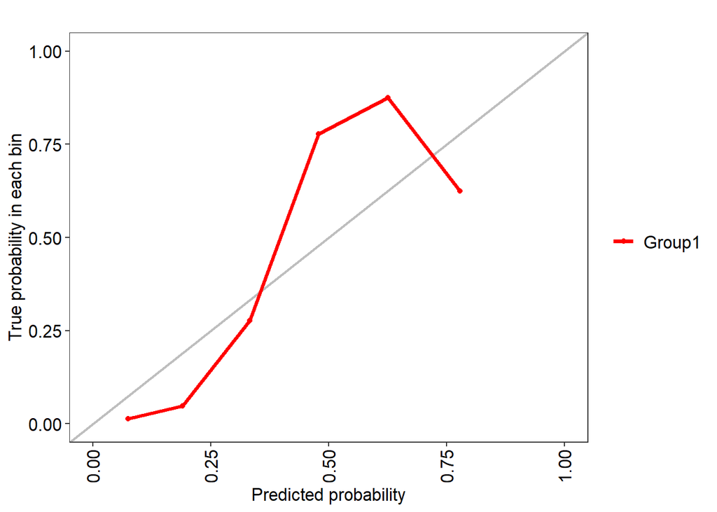

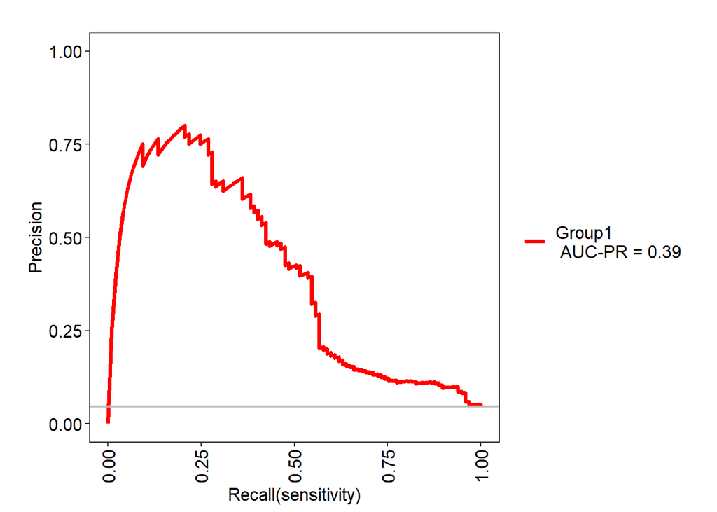

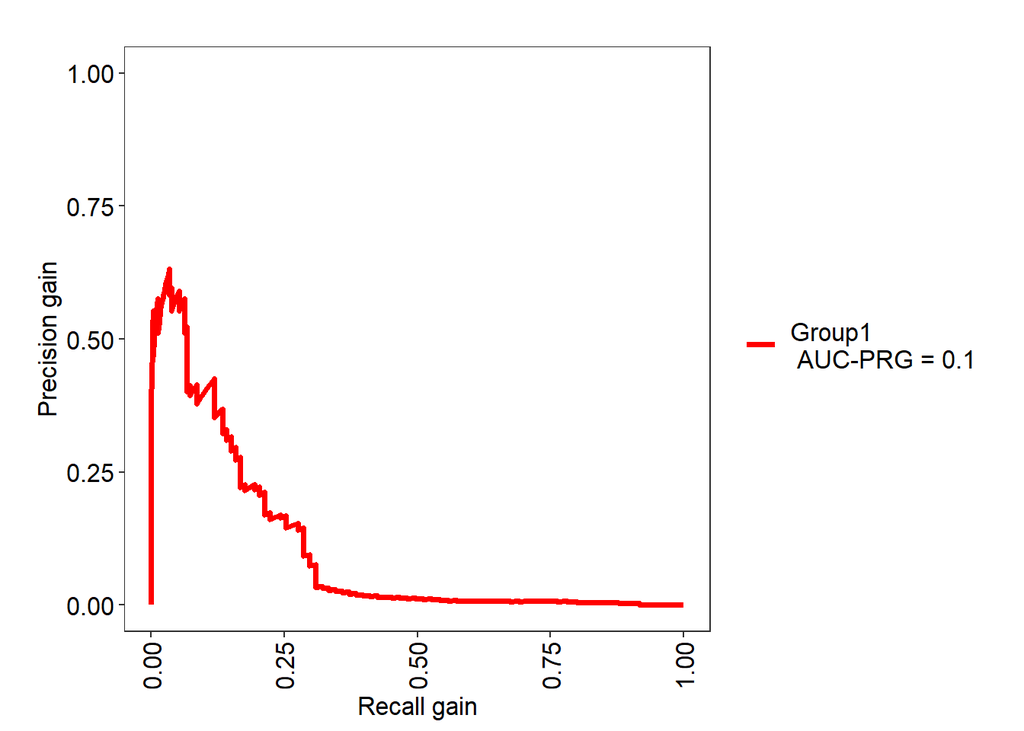

```
## Group1 Optimal Informedness = 0.532967176807527
```

```
## Group1 AUC-ROC = 0.85
```

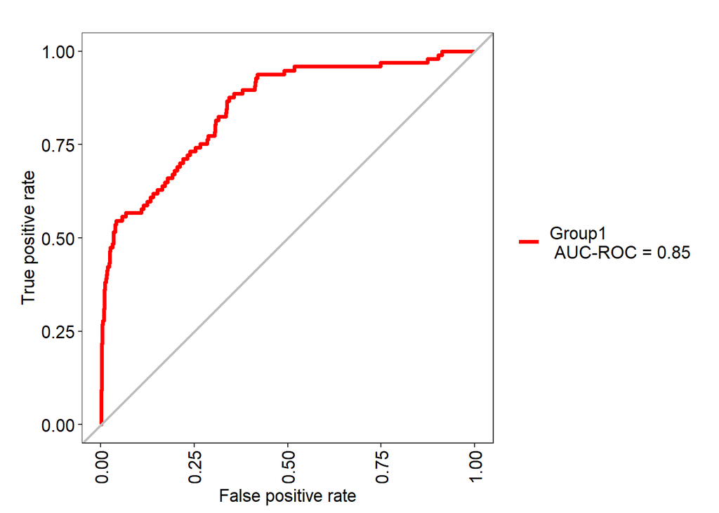

### 7.4 Logistic Regrssion Analysis

#### Model 4A: Logistic Regression with Normalisation, SMOTE & Cross Validation

```r
# Model 4A
# 10-fold cross validation
train_control <- trainControl(method="repeatedcv", number=10, repeats=1, classProbs=TRUE)
#lr_cv_smote_z <- train(class~., data=smote_z_train_set, trControl=train_control, method="glm", family="binomial")
#saveRDS(lr_cv_smote_z, "lr_cv_smote_z.rds")
lr_cv_smote_z <- readRDS("lr_cv_smote_z.rds")
lr_cv_smote_z
```

```
## Generalized Linear Model
##
## 8993 samples
##   23 predictor
##    2 classes: 'Sustain', 'Bankrupt'
##
## No pre-processing
## Resampling: Cross-Validated (10 fold, repeated 1 times)
## Summary of sample sizes: 8094, 8093, 8094, 8093, 8094, 8094, ...
## Resampling results:
##
##   Accuracy  Kappa
##   0.558996  0.1442598
```

```r
# Predict Sustain or Bankrupt for z_test_set
pred4a <- predict(lr_cv_smote_z, newdata=z_test_set, type="prob")
test4a <- evalm(data.frame(pred4a, z_test_set$class)) #AUC-ROC = 0.53
```

```
## ***MLeval: Machine Learning Model Evaluation***
```

```
## Input: data frame of probabilities of observed labels
```

```
## Group does not exist, making column.
```

```
## Observations: 2066
```

```
## Number of groups: 1
```

```
## Observations per group: 2066
```

```
## Positive: Bankrupt
```

```
## Negative: Sustain
```

```
## Group: Group1
```

```
## Positive: 97
```

```
## Negative: 1969
```

```
## ***Performance Metrics***
```

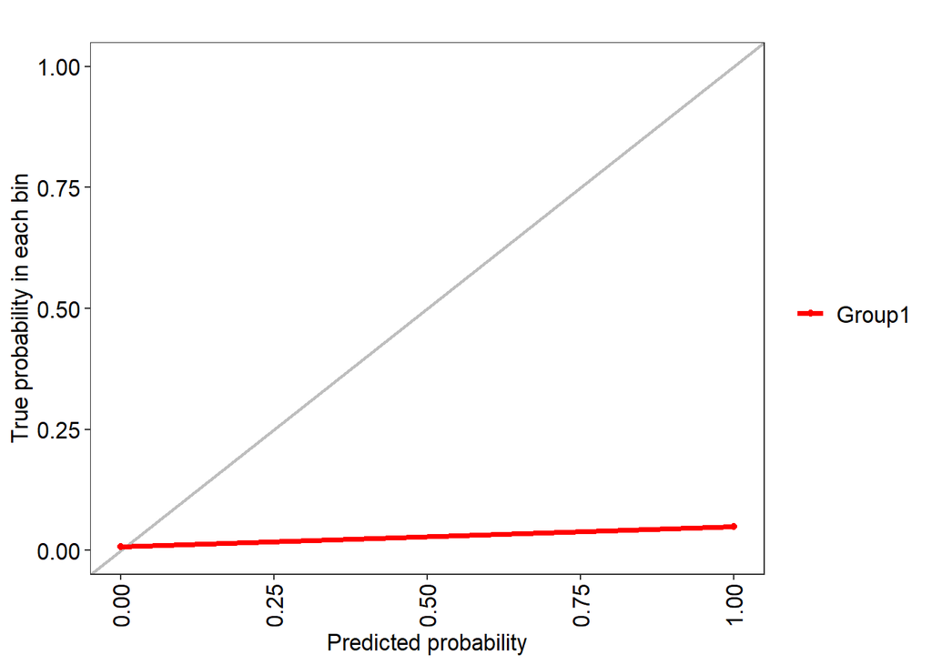

[figure not shown]

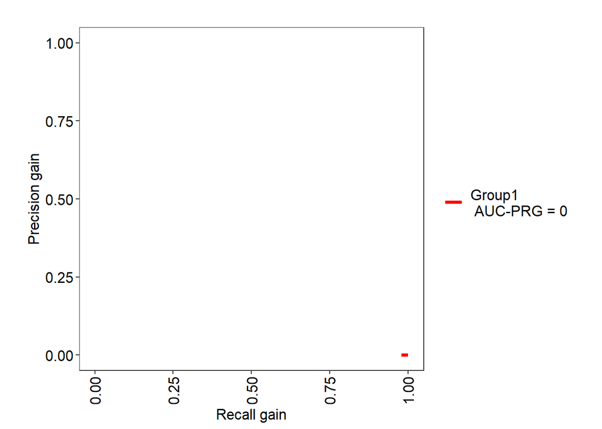

```
## Group1 Optimal Informedness = 0.0552062117459802
```

```
## Group1 AUC-ROC = 0.53
```

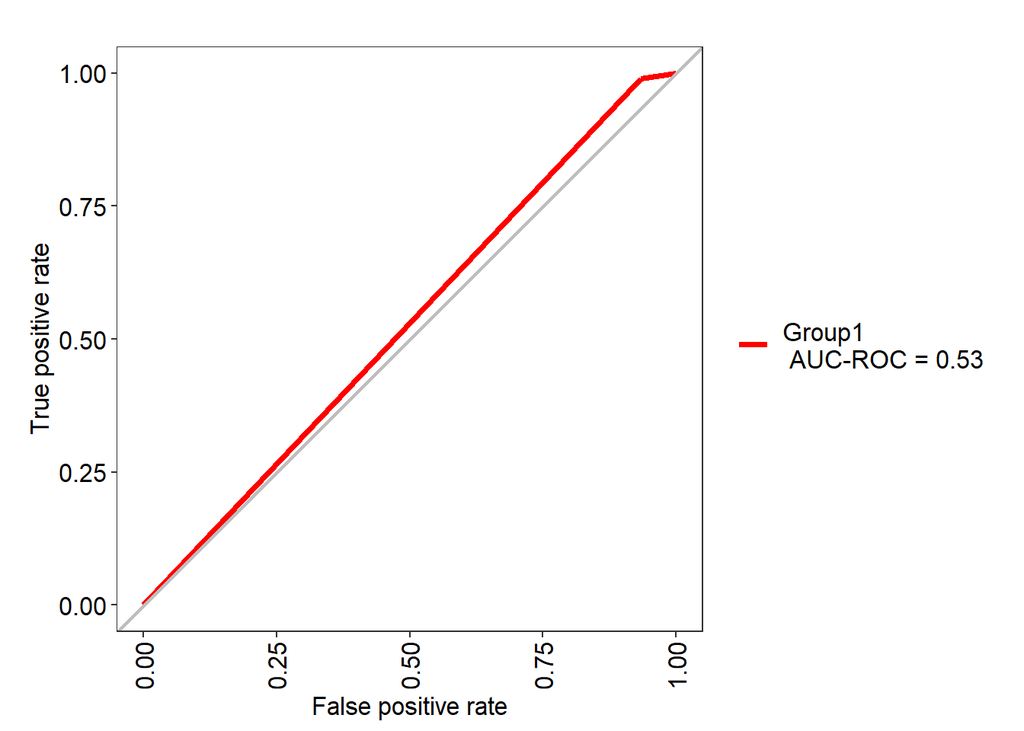

#### Model 4B: Logistic Regression with SMOTE & Cross Validation

```r
# Model 4B
# 10-fold cross validation
train_control <- trainControl(method="repeatedcv", number=10, repeats=1, classProbs=TRUE)
#lr_cv_smote <- train(class~., data=smote_train_set, trControl=train_control, method="glm", family="binomial")
#saveRDS(lr_cv_smote, "lr_cv_smote.rds")
lr_cv_smote <- readRDS("lr_cv_smote.rds")
lr_cv_smote
```

```
## Generalized Linear Model
##
## 8993 samples
##   23 predictor
##    2 classes: 'Sustain', 'Bankrupt'
##
## No pre-processing
## Resampling: Cross-Validated (10 fold, repeated 1 times)
## Summary of sample sizes: 8093, 8094, 8094, 8094, 8094, 8094, ...
## Resampling results:
##
##   Accuracy   Kappa
##   0.5682223  0.1555512
```

```r
# Predict Sustain or Bankrupt for test_set
pred4b <- predict(lr_cv_smote, newdata=test_set, type="prob")
test4b <- evalm(data.frame(pred4b, test_set$class)) #AUC-ROC = 0.53
```

```
## ***MLeval: Machine Learning Model Evaluation***
```

```
## Input: data frame of probabilities of observed labels
```

```
## Group does not exist, making column.
```

```
## Observations: 2066
```

```
## Number of groups: 1
```

```
## Observations per group: 2066
```

```
## Positive: Bankrupt
```

```
## Negative: Sustain
```

```
## Group: Group1
```

```
## Positive: 97
```

```
## Negative: 1969
```

```
## ***Performance Metrics***
```

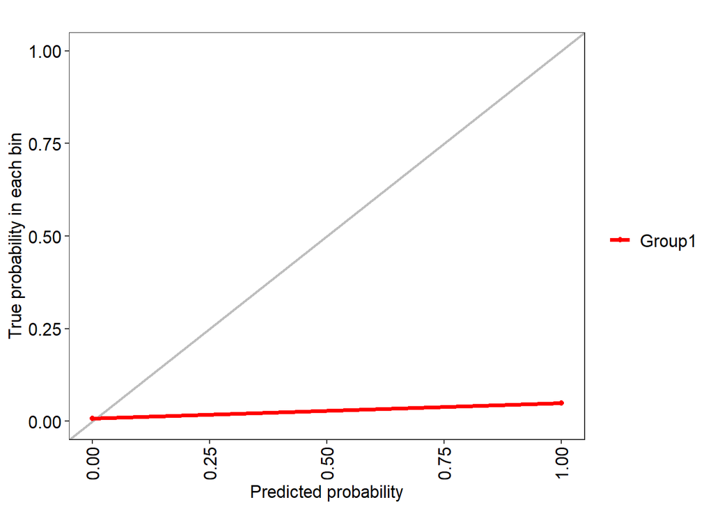

[figure not shown]

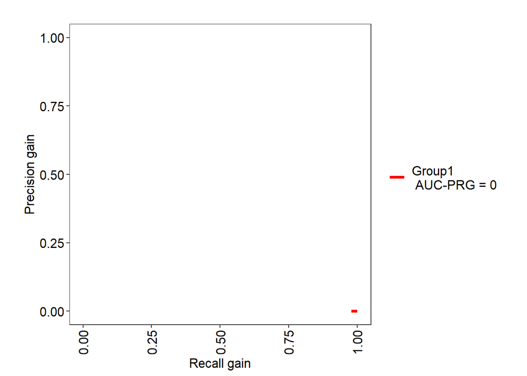

```
## Group1 Optimal Informedness = 0.0552062117459802
```

```
## Group1 AUC-ROC = 0.53
```

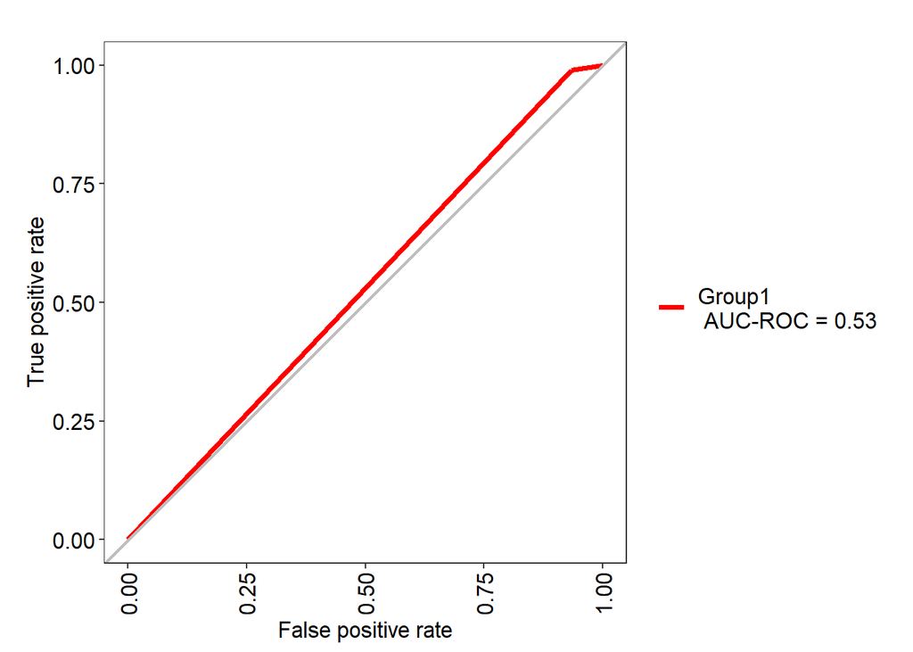

#### Model 4C: Logistic Regression with Normalisation & Cross Validation

```r
# Model 4C
# 10-fold cross validation
train_control <- trainControl(method="repeatedcv", number=10, repeats=1, classProbs=TRUE)
#lr_cv_z <- train(class~., data=z_train_set, trControl=train_control, method="glm", family="binomial")
#saveRDS(lr_cv_z, "lr_cv_z.rds")
lr_cv_z <- readRDS("lr_cv_z.rds")
lr_cv_z
```

```
## Generalized Linear Model
##
## 8269 samples
##   23 predictor
##    2 classes: 'Sustain', 'Bankrupt'
##
## No pre-processing
## Resampling: Cross-Validated (10 fold, repeated 1 times)
## Summary of sample sizes: 7442, 7442, 7442, 7441, 7442, 7442, ...
## Resampling results:
##
##   Accuracy  Kappa
##   0.933247  0.005746195
```

```r
# Predict Sustain or Bankrupt for z_test_set
pred4c <- predict(lr_cv_z, newdata=z_test_set, type="prob")
test4c <- evalm(data.frame(pred4c, z_test_set$class)) #AUC-ROC = 0.67
```

```
## ***MLeval: Machine Learning Model Evaluation***
```

```
## Input: data frame of probabilities of observed labels
```

```
## Group does not exist, making column.
```

```
## Observations: 2066
```

```
## Number of groups: 1
```

```
## Observations per group: 2066
```

```
## Positive: Bankrupt
```

```
## Negative: Sustain
```

```
## Group: Group1
```

```
## Positive: 97
```

```
## Negative: 1969
```

```
## ***Performance Metrics***
```

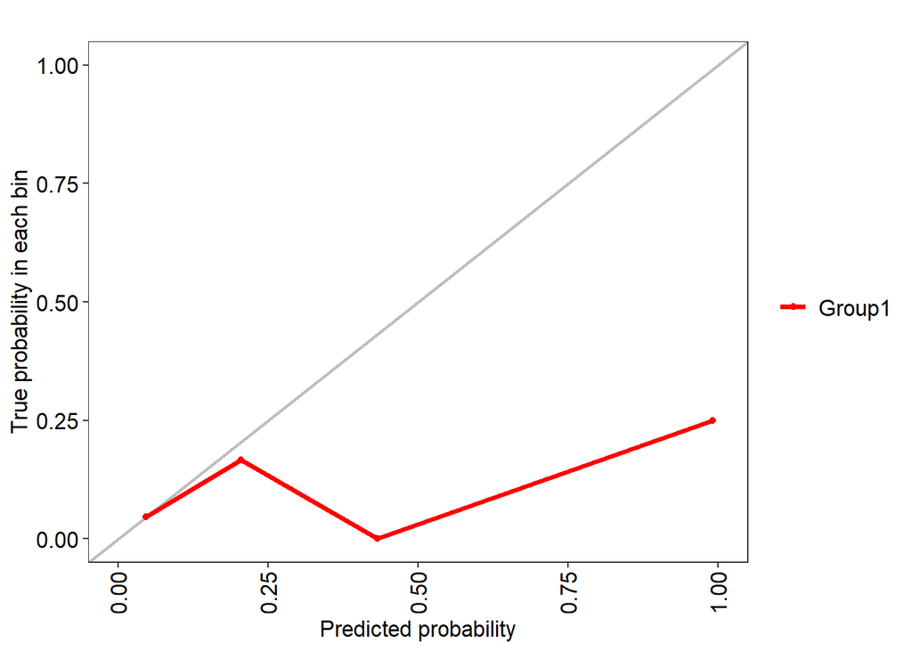

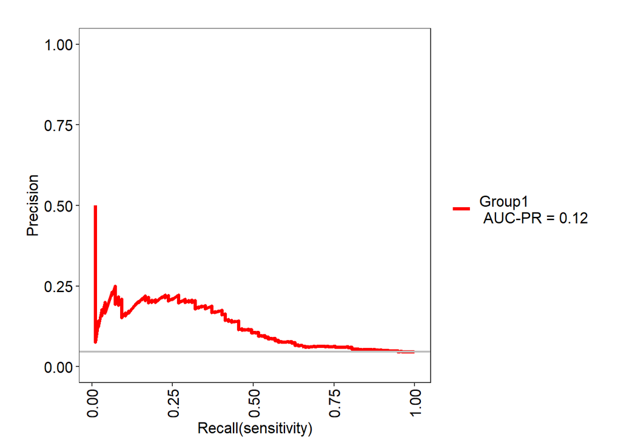

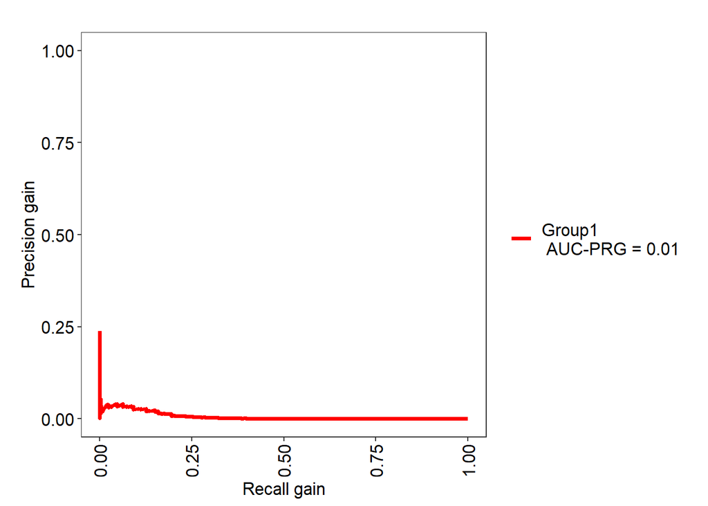

```
## Group1 Optimal Informedness = 0.319022163115926
```

```
## Group1 AUC-ROC = 0.67
```

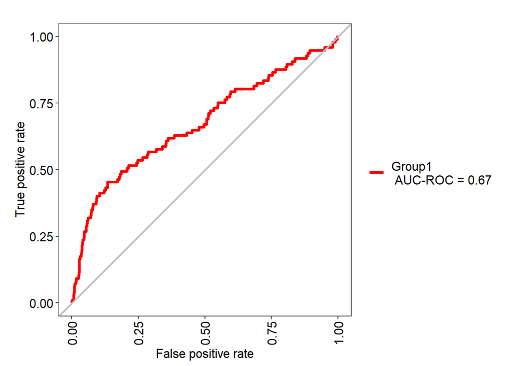

### 7.5 Identifying Important Financial Ratios Associated with Bankruptcy through Logistic Regression Model

Since Model 4C has the highest AUC-ROC among the Logistic Regression models (4A, 4B and 4C), it will be used to identify the top five most important financial ratios associated with company’s bankruptcy in Poland.

Attributes with higher absolute Z-score (“absZ” column in the table below) are more important features in the Logistic Regression model. The direction of correlation between attribute and likelihood of bankruptcy can be determined based on the sign of the coefficient (“Estimate” column in the table below).

```r
c = as.data.frame(summary(lr_cv_z)[["coefficients"]])
c$absZ = abs(c[,3])
c = arrange(c, desc(absZ))
c
```

```
##                  Estimate  Std. Error      z value     Pr(>|z|)        absZ
## (Intercept) -5.532705e+00  0.51975068 -10.64492103 1.841403e-26 10.64492103
## Attr21      -1.839583e+02 39.32481258  -4.67791829 2.898020e-06  4.67791829
## Attr9       -7.057676e-01  0.19986121  -3.53128838 4.135406e-04  3.53128838
## Attr2        9.247990e-01  0.36911304   2.50546273 1.222913e-02  2.50546273
## Attr29      -9.656030e-02  0.05658705  -1.70640270 8.793313e-02  1.70640270
## Attr18      -1.997187e+00  1.45037549  -1.37701407 1.685079e-01  1.37701407
## Attr55      -1.203772e-01  0.09169592  -1.31278727 1.892546e-01  1.31278727
## Attr1        8.781461e-01  0.88281348   0.99471309 3.198758e-01  0.99471309
## Attr39       2.985486e-02  0.03066538   0.97356869 3.302707e-01  0.97356869
## Attr41      -1.372443e+01 14.68542342  -0.93456171 3.500142e-01  0.93456171
## Attr47      -9.030215e+00 10.13971656  -0.89057868 3.731552e-01  0.89057868
## Attr15       9.428851e-02  0.12787534   0.73734712 4.609113e-01  0.73734712
## Attr4        3.833549e-02  0.07467024   0.51339713 6.076736e-01  0.51339713
## Attr61      -6.251657e-02  0.12432951  -0.50282968 6.150840e-01  0.50282968
## Attr8       -5.381416e-01  1.10367491  -0.48759069 6.258398e-01  0.48759069
## Attr60      -1.388392e+00  3.07173523  -0.45198934 6.512767e-01  0.45198934
## Attr57      -1.176770e-02  0.02730288  -0.43100583 6.664641e-01  0.43100583
## Attr27      -6.308105e-02  0.20885929  -0.30202655 7.626318e-01  0.30202655
## Attr34       2.255153e-02  0.09258197   0.24358442 8.075527e-01  0.24358442
## Attr32      -4.439757e-02  0.27382317  -0.16213958 8.711959e-01  0.16213958
## Attr5        4.408428e-02  0.28618507   0.15404117 8.775773e-01  0.15404117
## Attr28       5.670485e-03  0.05073391   0.11176913 9.110065e-01  0.11176913
## Attr45      -3.601777e-02  0.45226491  -0.07963866 9.365246e-01  0.07963866
## Attr20      -1.282236e-03  0.05762310  -0.02225212 9.822468e-01  0.02225212
```

The top five most important financial ratios in descending order and their direction of correlation are:

- Attr21 : sales (n) / sales (n-1) : Higher sales growth tends to have a lower likelihood of bankruptcy.
- Attr9 : sales / total assets : Higher sales-to-asset ratio tends to have a lower likelihood of bankruptcy.
- Attr2 : total liabilities / total assets : Higher liability-to-asset ratio tends to have a higher likelihood of bankruptcy.
- Attr29 : logarithm of total assets : Larger company by total asset size tends to have a lower likelihood of bankruptcy.
- Attr18 : gross profit / total assets : Higher profit-to-asset ratio tends to have a lower likelihood of bankruptcy.

## 8. Results

As the “class” is considerably imbalanced (majority : minority = Sustain : Bankrupt = 95% : 5%), using Accuracy [= (TP + TN) / Total] as performance metric is misleading. This is because Accuracy is largely influenced by the majority class results even there is high inaccuracy in the minority class.

In our project, Area Under Curve of Receiver Operating Characteristic (**AUC-ROC**) will be adopted as the model performance metric to address this issue. AUC-ROC of 1 indicates a perfect classifier, whilst AUC-ROC of 0.5 (45-degree line) means random guessing. The AUC-ROC for all 12 models are tabulated in **Table 8.1**.

**Table 8.1**: Performance of 12 machine learning models

| Model | Machine Learning Type | Machine Learning Method | Z-Score Normalisation | SMOTE | 10-Fold Cross Validation | AUC-ROC |
| --- | --- | --- | --- | --- | --- | --- |
| 1A | Classification | Random Forest | Yes | Yes | Yes | 0.83 |
| 1B | Classification | Random Forest | - | Yes | Yes | 0.83 |
| 1C | Classification | Random Forest | Yes | - | Yes | 0.83 |
| 2A | Classification | k-Nearest Neighbours | Yes | Yes | Yes | 0.60 |
| 2B | Classification | k-Nearest Neighbours | - | Yes | Yes | 0.62 |
| 2C | Classification | k-Nearest Neighbours | Yes | - | Yes | 0.57 |
| 3A | Classification | AdaBoost | Yes | Yes | Yes | 0.84 |
| 3B | Classification | AdaBoost | - | Yes | Yes | 0.84 |
| **3C** | **Classification** | **AdaBoost** | **Yes** | **-** | **Yes** | **0.85** |
| 4A | Regression | Logistic Regression | Yes | Yes | Yes | 0.53 |
| 4B | Regression | Logistic Regression | - | Yes | Yes | 0.53 |
| 4C | Regression | Logistic Regression | Yes | - | Yes | 0.67 |

The results show that **Model 3C** (AdaBoost Classification with Z-score normalisation and 10-fold cross validation) is the **best classifier** among the rest and it achieved an AUC-ROC of 0.85.

In terms of machine learning method, AdaBoost (0.84-0.85) and Random Forest (0.83) outperformed k-Nearest Neighbours (0.57-0.62) and Logistic Regression (0.53-0.67).

## 9. Conclusions

1. Nine (9) classification models and three (3) regression models were built in this project to predict whether a Polish company will sustain or bankrupt based on the financial ratios provided.
2. Model 3C is the best classifier model amongst all the 12 models. It is an AdaBoost Classification model fed with Z-score normalised data and trained with 10-fold cross validation.
3. The top five most important financial ratios in descending order obtained from the Logistic Regression Model 4C are:
- Attr21 : sales (n) / sales (n-1)
- Attr9 : sales / total assets
- Attr2 : total liabilities / total assets
- Attr29 : logarithm of total assets
- Attr18 : gross profit / total assets

The findings from the models are intuitive. Higher sales (Attr21 and Attr9) often brings more cash inflow into the company, hence lowering liquidity risk and bankruptcy risk.

A company with high leverage (Attr2) (i.e. high debt or liabilities relative to company size) may face higher difficulty in servicing loan interest and debt principal repayment, thus leading to a higher risk of bankruptcy.

A larger company (Attr29), on the other hand, often has more established management and operational processes, therefore reducing the risk of bankruptcy.

Companies which are profitable (Attr18) has a lower risk of bankruptcy inherently.

## References

Altman, E. I. (1968). Financial ratios, discriminant analysis and the prediction of corporate bankruptcy. *The Journal of Finance*, *23*(4), 589–609. https://doi.org/10.1111/j.1540-6261.1968.tb00843.x

Cambridge University Press. (2022, May 27). *Cambridge dictionary*. https://dictionary.cambridge.org/dictionary/english/bankrupt

Financial Crisis Inquiry Commission. (2011). *The financial crisis inquiry report: Final report of the national commission on the causes of the financial and economic crisis in the United States*. https://books.google.com.my/books?id=QIKfTVrhNfMC&pg=PA352&redir_esc=y#v=onepage&q&f=false

Tomczak, S. K. (2016). *Polish companies bankruptcy data* [Dataset]. UCI Machine Learning Repository. https://archive.ics.uci.edu/ml/datasets/Polish+companies+bankruptcy+data

Wang, H., & Liu, X. (2021). Undersampling bankruptcy prediction: Taiwan bankruptcy data. *PLoS ONE*, *16*(7), e0254030. https://doi.org/10.1371/journal.pone.0254030